# Stat 436 Milestone 2 Submission. Group 7

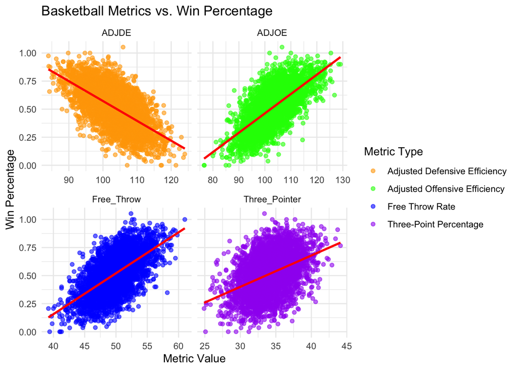

```r
# Load data
#https://www.kaggle.com/datasets/andrewsundberg/college-basketball-dataset/data

college_data = read.csv("https://uwmadison.box.com/shared/static/ohboihasjox7imnqn926v434sstj8fzs.csv")

# Data cleaning
college_data <- college_data %>%
  rename("Conference" = CONF,
         "Games" = G,
         "Wins" = W,
         "Power_Rate" = BARTHAG,
         "Free_Throw" = EFG_O,
         "Turnover" = TORD,
         "Rebound" = ORB,
         "Two_Pointer" = X2P_O,
         "Three_Pointer" = X3P_O,
         "Tempo" = ADJ_T) %>%
  mutate(Win_Percentage = Wins / Games)  # Calculate Win Percentage

# Reshape data to long format for faceting
college_data_long <- college_data %>%
  pivot_longer(cols = c(Free_Throw, Three_Pointer, ADJOE, ADJDE),
               names_to = "Metric",
               values_to = "Value")

# Specify legend labels
legend_labels <- c("Free_Throw" = "Free Throw Rate",
                   "Three_Pointer" = "Three-Point Percentage",
                   "ADJOE" = "Adjusted Offensive Efficiency",
                   "ADJDE" = "Adjusted Defensive Efficiency")

# Scatterplots
ggplot(college_data_long, aes(x = Value, y = Win_Percentage, color = Metric)) +
  geom_point(alpha = 0.6) +
  geom_smooth(method = "lm", se = FALSE, col = "red") +
  facet_wrap(~ Metric, scales = "free_x") +
  scale_color_manual(
    values = c("Free_Throw" = "blue",
               "Three_Pointer" = "purple",
               "ADJOE" = "green",
               "ADJDE" = "orange"),
    labels = legend_labels
  ) +
  labs(title = "Basketball Metrics vs. Win Percentage",
       x = "Metric Value",
       y = "Win Percentage",
       color = "Metric Type") +
  theme_minimal()
```

Scatterplots identify relationships, trends, and patterns between two continuous variables. By plotting individual data points, scatterplots visualize correlations, clusters, and potential outliers. In this dataset, we examined the relationship between key basketball metrics and team success (win percentage) using scatterplots. We employed a faceted approach to compare four metrics (Free throw rate, Three-point percentage, Adjusted offensive efficiency, and Adjusted defensive efficiency) in separate panels. To enhance clarity, we color-coded by metric and added regression lines to highlight overall trends. This visualization provides insight into the strength and direction of the relationship between performance factors and team success.

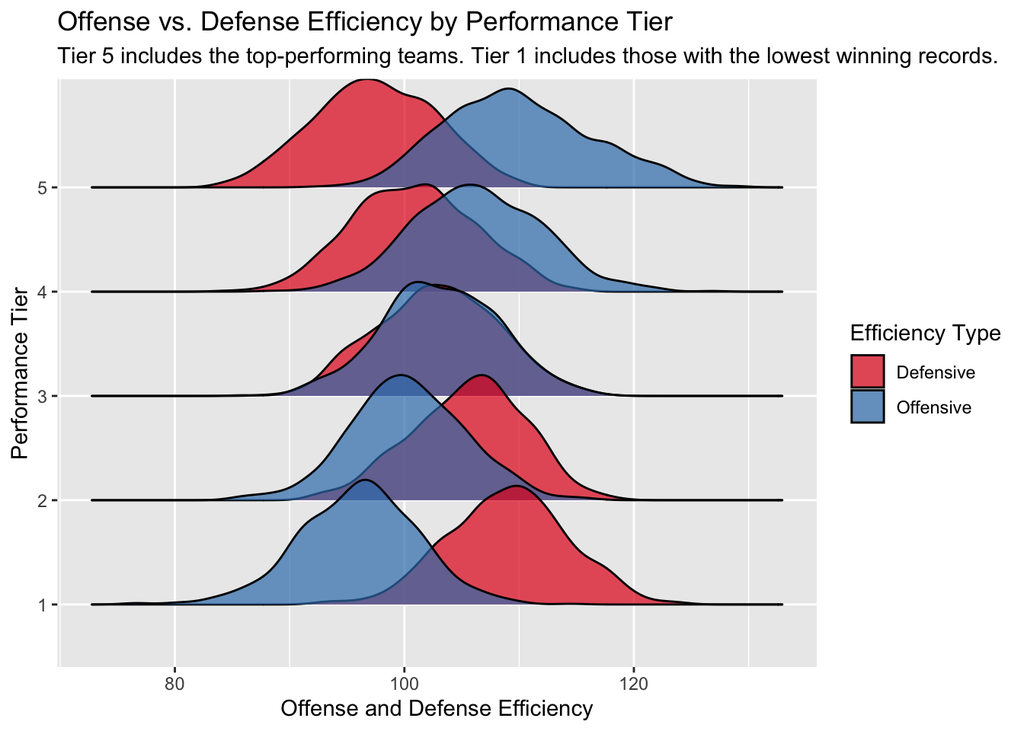

```r
college_data = read.csv("https://uwmadison.box.com/shared/static/ohboihasjox7imnqn926v434sstj8fzs.csv")
college_data <- college_data %>%
  rename("Conference" = CONF,
         "Games" = G,
         "Wins" = W,
         "Power_Rate" = BARTHAG,
         "Free_Throw" = EFG_O,
         "Turnover" = TORD,
         "Rebound" = ORB,
         "Two_Pointer" = X2P_O,
         "Three_Pointer" = X3P_O,
         "Tempo" = ADJ_T) %>%
  mutate(Win_Percentage = Wins / Games)  # Calculate Win %

data_for_density <- college_data %>%
  mutate(Performance_Tier = ntile(Win_Percentage,5) %>% as.factor()) %>% # group teams to five tiers by winning rate
  pivot_longer(cols = c(ADJOE, ADJDE),
               names_to = "Efficiency_Type",
               values_to = "Efficiency")

ggplot(data = data_for_density,
       aes(x = Efficiency,
           y = Performance_Tier,
           fill = Efficiency_Type)) +
  geom_density_ridges(alpha = 0.7, scale = 1.2) +
  labs(title = "Offense vs. Defense Efficiency by Performance Tier",
       subtitle = "Tier 5 includes the top-performing teams. Tier 1 includes those with the lowest winning records.",
       x = "Offense and Defense Efficiency",
       y = "Performance Tier",
       fill = "Efficiency Type") +
  scale_fill_brewer(labels = c("ADJOE" = "Offensive", "ADJDE" = "Defensive"),
                    palette = "Set1")
```

This visualization is a ridge plot which shows the distribution of defensive and offensive efficiency by 5 performance tier (College teams were grouped to five tiers by winning rate in advance using ntile command). We can see significant differences in these two efficiencies between different tiers. Top-performing teams have higher offensive efficiency and lower defensive efficiency, which means offensive and defensive efficiency are two important variables for predicting the winning rate.

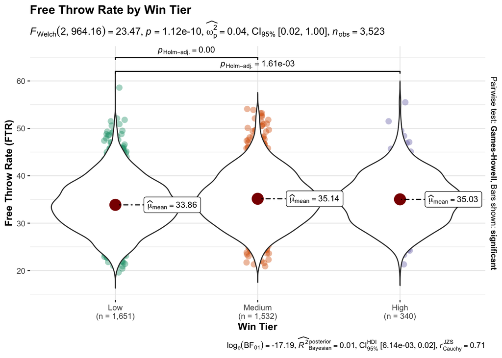

```r
df <- read.csv("https://uwmadison.box.com/shared/static/ohboihasjox7imnqn926v434sstj8fzs.csv")

# Compute win ratio and categorize teams into tiers
df$WIN_RATIO <- df$W / df$G

df$WIN_TIER <- cut(
  df$WIN_RATIO,
  breaks = c(-Inf, 0.5, 0.75, Inf),
  labels = c("Low", "Medium", "High")
)

# Violin Plot - Free Throw Rate by Win Tier
ggbetweenstats(
  data = df,
  x = "WIN_TIER",
  y = "FTR",
  title = "Free Throw Rate by Win Tier",
  xlab = "Win Tier",
  ylab = "Free Throw Rate (FTR)",
  type = "parametric",
  violin.args = list(trim = FALSE),
  messages = FALSE
)
```